# Ford GoBike System Data

## by Mohamed Galloul

## Dataset Description

> This data set includes information about individual rides made in a bike-sharing system covering the greater San Francisco Bay area. [source](https://www.bikeshare.com/data/)

### What is the structure of your dataset?

This dataset contains 183413 rows (before cleaning) and 16 columns named as following:

- Trip Duration (seconds)
- Start Time and Date
- Stop Time and Date
- Start Station Name
- End Station Name
- Station ID
- Station Lat/Long
- Bike ID
- User Type (Customer = 24-hour pass or 3-day pass user; Subscriber = Annual Member)
- Gender (Zero=unknown; 1=male; 2=female)
- Year of Birth
- *bike_share_for_all_trip* which tracks members who are enrolled in the Bike Share for All program for low-income residents

### What is/are the main feature(s) of interest in your dataset?

> The Duration of the ride.

### What features in the dataset do you think will help support your investigation into your feature(s) of interest?

> Mainly factors that are related to longer rides including member year of birth, gender of the member (Male/Female/Other), member type (Subscriber/Customer), and if the member uses bike share for all the trip or not.

## Univariate Exploration

### What is the year of the birth interval that has most members born in?

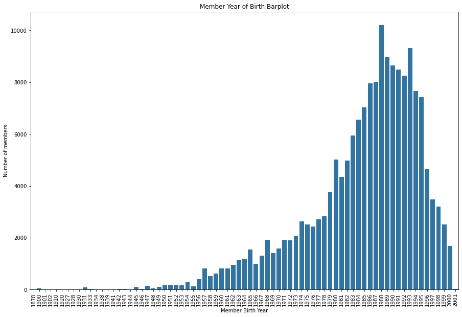

```python
color = sb.color_palette()[0]
plt.figure(figsize=[15,10])
sb.countplot(bikeSharing.member_birth_year, color=color);
plt.xticks(rotation=90)
plt.xlabel('Member Birth Year')
plt.ylabel('Number of members')
plt.title('Member Year of Birth Barplot');
```

### What is the distance between the start station and end station usually be?

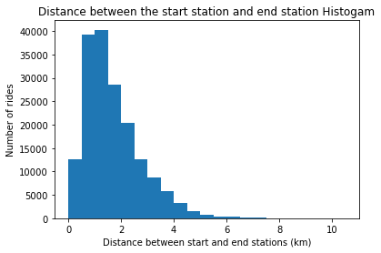

```python
plt.hist(bikeSharing[bikeSharing.distance < 20.0].distance, bins = np.arange(0, 10+1, 0.5))
plt.xlabel('Distance between start and end stations (km)')
plt.ylabel('Number of rides')
plt.title('Distance between the start station and end station Histogam');
```

> **Observations:** As we mentioned before that generation the distance between the start and end stations can be misleading and nonintuitive since this distance doesn't consider the ride track so basically the member can take the bike from a certain start station and then return it to the same station so the distance will be 0 as shown in the plot!  
> We also found extraordinary rides that distances of more than 10 km in fact they are only 9 rides out of the 174952 rides.  
> Since this feature won't be a good indicator for the duration of the ride we will keep it, just to get a sense of the distance between the start point and endpoint of the ride.

## Bivariate Exploration

### What is the relation between End Hour and Start Hour of the trips?

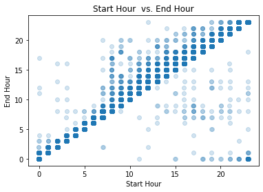

```python
# sb.regplot(data=bikeSharing, y ='end_hour', x= 'start_hour',x_jitter = 0.04,scatter_kws={'alpha':0.2})
custum_scatter(x='start_hour', y='end_hour',
                   xlabel='Start Hour',
                   ylabel='End Hour',
                   title='Start Hour  vs. End Hour')
```

> **Observation:** Since we already knew start hour and end hour are correlated the straight diagonal line shows that clearly which also means that the members return their bike at the same hour they took their bike at. As we go up the diagonal line the members return their bike in the next hours and vice versa. We can clearly see that members usually tend to return their bike just within the same hour or within the next 3 to 4 hours.

### What is the year of birth for the members who had a long trip duration?

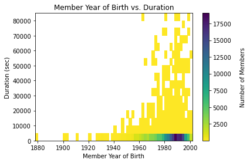

```python
bins_x = np.arange(bikeSharing.member_birth_year.min(), bikeSharing.member_birth_year.max()+2, 2)
bins_y = np.arange(0, bikeSharing.duration_sec.max()+5000, 5000)
plt.hist2d(data = bikeSharing, y = 'duration_sec', x = 'member_birth_year',
           cmin=0.5, cmap='viridis_r',bins= [bins_x, bins_y])

plt.xlabel('Member Year of Birth')
plt.ylabel('Duration (sec)')
plt.title('Member Year of Birth vs. Duration')
# plt.colorbar(label = 'Number of Members')
plt.colorbar().ax.set_ylabel('Number of Members', rotation=90,labelpad=15);
```

> **Observation:** Since we already know that most of the members were born in [1980, 2000] this heatmap clearly insures that also the heat map shows that majority of members were born in [1985, 1995] specifically.  
> Since we are interested in know the effect of year of birth on the trip duration we can clearly see that members who were born in [1950, 2000] can do longer trips (more than 10000 sec)

## Multivariate Exploration

### Does the gender of the member is related to longer trips for different User Types?

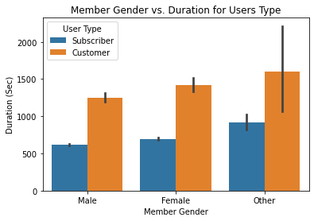

```python
# sb.barplot(data=bikeSharing, y ='duration_sec', x= 'user_type')
custom_barplot2d(y='duration_sec', x='member_gender',hue='user_type',
                 xlabel='Member Gender',
                 ylabel='Duration (Sec)',
                 title='Member Gender vs. Duration for Users Type')
plt.legend(title = 'User Type');
```

> **Observation:** We already know that female member tends to have longer trips than male members but what is interesting in the above barplot is despite the gender of the member customers have longer trips than normal subscribers which is unexpected since customers only use the bike service for only 24 hours or 3 days while subscribers have an annual subscription!

### Does the gender of the member is related to longer trips for the members that use Bike Share for all the trip?

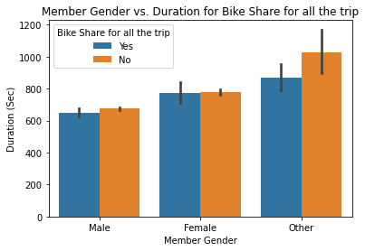

```python
# sb.barplot(data=bikeSharing, y ='duration_sec', x= 'bike_share_for_all_trip')
custom_barplot2d(y='duration_sec', x='member_gender',hue='bike_share_for_all_trip',
                 xlabel='Member Gender',
                 ylabel='Duration (Sec)',
                 title='Member Gender vs. Duration for Bike Share for all the trip')
plt.legend(title = 'Bike Share for all the trip');
```

> Male and female members who don't use the bike share for all the trips have slightly longer trips than those who do.

### What is the relation between the Duration of the trip and the Member Year of Birth for each gender and user type?

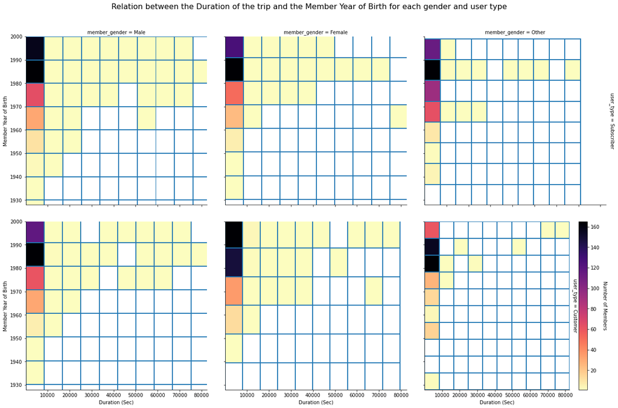

```python
g = sb.FacetGrid(data=bikeSharing, col='member_gender',row='user_type',height= 6, margin_titles=True)
g = g.map(plt.hist2d, 'duration_sec','member_birth_year',cmin=0.5,cmap = 'magma_r')

g.fig.subplots_adjust(hspace=0.1,wspace= 0.1,top = 0.9)
g.set_axis_labels('Duration (Sec)', 'Member Year of Birth')
g.fig.suptitle('Relation between the Duration of the trip and the Member Year of Birth for each gender and user type',fontsize=16)
plt.colorbar().ax.set_ylabel('Number of Members', rotation=270,labelpad=15);
```